# Lab 7. Logistic Regression

Junsik Kim

## 1. Sensitivity, Specificity

Assume that there is 2 variables $X,Y$ s.t
$$\begin{eqnarray*}
X & =& \left \{ \begin{array}{ccl} 1 & & \mbox{disease}\\ 2 & & \mbox{otherwise} \end{array} \right. \\
\\
Y & = &\left \{ \begin{array}{ccl} 1 & & \mbox{Test is Positive}\\ 2 & & \mbox{Test is Negative} \end{array} \right. \end{eqnarray*}$$

- Sensitivity : $P(Y=1 | X=1)$
- Specificity : $P(Y=2 | X=2)$

$\Rightarrow$ The higher Sensitivity and Specificity implies the more accurate test is.

```r
Disease = c("Disease","Normal")
Test = c("Positive","Negative")
ex_1 = expand.grid(Test=Test,Disease=Disease)
val_1 = c(9,1,89,1024)
table_1 = cbind(ex_1,count=val_1)
ex_tab_1= xtabs(formula = count ~ Test + Disease, data = table_1)
ex_tab_1
```

```
##           Disease
## Test       Disease Normal
##   Positive       9     89
##   Negative       1   1024
```

```r
cat("The Sensitive is =", ex_tab_1[1,1]/(ex_tab_1[1,1]+ex_tab_1[2,1]), "and the Specificity is =", ex_tab_1[2,2]/(ex_tab_1[2,2]+ex_tab_1[1,2]))
```

```
## The Sensitive is = 0.9 and the Specificity is = 0.9200359
```

## 2. Observational study

- Observation study : A method of observing who belongs to a group and what reaction results.
- Ex1. Case control study : A study designed to look back on the past. (retrospective)
- EX2. Clinical trial : Randomly assigns subjects to groups.
- Ex3. Cohort study : (Prospective) After making each individual choose which group he or she belongs to, he or she are observed whether or not have outcome such as disease. The total number of each row $N_{i+}$ is fixed.
- Ex4. Cross-sectional study : (Prospective) Samples are collected and grouped according to group status and response variables at the same time. Total number N is fixed.
- cf. Experimental study : After the researcher decides which subjects belong to each group, and analyzes the results.

## 3. Difference of Proportions(DP), Relative Risk(RR), Odds Ratio(O)

- When $DP$ is nearly zero on both groups, we need to consider $RR$ or $OR$…
- Also even though $DP$ are same, $RR$ can be different.
- EX. $\pi_{1|1}=0.0100$, $\pi_{1|2}=0.001$ vs. $\pi_{1|1}=0.410$, $\pi_{1|2}=0.401$ $\rightarrow$ $RR=10$ vs. $RR=1.02$
- When the ratios of success are nearly zero on both groups, then $OR$ is nearly same with $RR$.
  $$OR = RR \times \frac{1−p_2}{1−p_1}$$
- The relation between $RR$ and OR is useful, for example, for certain design we cannot calculate RR instead we can estimate $OR$ and using $OR$ we can obtiain $RR$ approximately.(under some condition, $OR \approx RR$)
- OR uses variables symmetrically so that we don’t need to consider response and explanatory variables separately

#### Example. The association of aspirin with myocardial infarction

In one study, one group participants were asked to take aspirin while the other group were given placebo and researcher check whether myocardial infarction occurred during the study.

```r
Disease = c("Disease","Normal")
Drug = c("Placebo","Aspirin")
ex_2 = expand.grid(Drug=Drug,Disease=Disease)
val_2 = c(189,104,10845,10933)
table_2 = cbind(ex_2,count=val_2)
ex_tab_2= xtabs(formula = count ~ Drug + Disease, data = table_2)
ex_tab_2
```

```
##          Disease
## Drug      Disease Normal
##   Placebo     189  10845
##   Aspirin     104  10933
```

```r
ex_2_pi.1=  ex_tab_2[1,1]/(ex_tab_2[1,1]+ex_tab_2[1,2])
ex_2_pi.2=  ex_tab_2[2,1]/(ex_tab_2[2,1]+ex_tab_2[2,2])
cat("The DP is =",ex_2_pi.1- ex_2_pi.2, "and the RR is =", ex_2_pi.1/ex_2_pi.2, "and the OR is =", ex_2_pi.1/(1-ex_2_pi.1)/(ex_2_pi.2/(1-ex_2_pi.2) ))
```

```
## The DP is = 0.007706024 and the RR is = 1.817802 and the OR is = 1.832054
```

- $DP=0.007706024 > 0$ means : Taking aspirin reduces risk of Disease. (Note that, actually we need to consider confidence interval)
- $RR=1.817802$ means : The group who took placebo than the group taking aspirin is 82% more likely to develop the disease. (Easy to interpret.)
- $OR=1.832054$ means : The OR estimate for the placebo group = 1.83*the OR estimate for group taking aspirin. (little bit tricky… but useful. For the general public, it is better to report relative risk because it is easier to interpret. )

#### Example. A research study estimated that under a certain condition, the probability that a subject would be referred for heart catheterization was 0.906 for whites and 0.847 for blacks.

1. Find the odds ratio (odds AA get hc to odds whites get hc).

```r
Catheterization = c("Yes","No")
Race = c("AA","W")
ex_2.11 = expand.grid(Race=Race,Catheterization=Catheterization)
val_2.11 = c(0.847,0.906,0.153,0.094)
table_2.11 = cbind(ex_2.11,count=val_2.11)
ex_tab_2.11= xtabs(formula = count ~ Race + Catheterization, data = table_2.11)
ex_tab_2.11
```

```
##     Catheterization
## Race   Yes    No
##   AA 0.847 0.153
##   W  0.906 0.094
```

```r
ex_2.11_pi.1=  ex_tab_2.11[1,1]/(ex_tab_2.11[1,1]+ex_tab_2.11[1,2])
ex_2.11_pi.2=  ex_tab_2.11[2,1]/(ex_tab_2.11[2,1]+ex_tab_2.11[2,2])
cat("The DP is =",ex_2.11_pi.1- ex_2.11_pi.2, "and the RR is =", ex_2.11_pi.1/ex_2.11_pi.2, "and the OR is =", ex_2.11_pi.1/(1-ex_2.11_pi.1)/(ex_2.11_pi.2/(1-ex_2.11_pi.2) ))
```

```
## The DP is = -0.059 and the RR is = 0.9348786 and the OR is = 0.5743699
```

2. An associated Press story described the study and said “Doctors were only 57% as likely to order cardiac catheterization for blacks as for whites.” Is this the correct interpretation? If not, give the correct percentage for this interpretation.
- ans : No, this is the interpretation of relative risk, not OR.

## 4. GLM for binary variable

- Read in the snoring/heart diseaese data set

```r
snore = data.frame(snore = c(0,2,4,5),yes=c(24,35,21,30),no=c(1355,603,192,224))
snore
```

```
##   snore yes   no
## 1     0  24 1355
## 2     2  35  603
## 3     4  21  192
## 4     5  30  224
```

- Compute the sample proportions

```r
snore.sample.props = snore$yes/(snore$yes+snore$no)
snore$sample_prop<-round(snore.sample.props,3)
snore
```

```
##   snore yes   no sample_prop
## 1     0  24 1355       0.017
## 2     2  35  603       0.055
## 3     4  21  192       0.099
## 4     5  30  224       0.118
```

- $Y_i \sim B(n_i, \pi_i)$
- $\mbox{logit}(\pi_i(x_i)) = \log \frac{\pi_i(x_i)}{1-\pi_i(x_i)} = \alpha + \beta x_i$
- $\pi_i(x) = \frac{\exp(\alpha + \beta x_i)}{1+\exp(\alpha + \beta_i x_i)}$
- run glm (family option in glm depends on distribution of response variable.)

```r
snore.glm_logit = glm(cbind(yes,no) ~ snore,data=snore,family=binomial(link = "logit"))
#cf. glm(yes/(yes+no) ~ snore,data=snore,family=binomial(),weights=yes+no)
```

- print out a summary of the fit

```r
summary(snore.glm_logit)
```

```
##
## Call:
## glm(formula = cbind(yes, no) ~ snore, family = binomial(link = "logit"),
##     data = snore)
##
## Deviance Residuals:
##       1        2        3        4
## -0.8346   1.2521   0.2758  -0.6845
##
## Coefficients:
##             Estimate Std. Error z value Pr(>|z|)
## (Intercept) -3.86625    0.16621 -23.261  < 2e-16 ***
## snore        0.39734    0.05001   7.945 1.94e-15 ***
## ---
## Signif. codes:  0 '***' 0.001 '**' 0.01 '*' 0.05 '.' 0.1 ' ' 1
##
## (Dispersion parameter for binomial family taken to be 1)
##
##     Null deviance: 65.9045  on 3  degrees of freedom
## Residual deviance:  2.8089  on 2  degrees of freedom
## AIC: 27.061
##
## Number of Fisher Scoring iterations: 4
```

- If we assign diffrent score (0,2,4,4.5), we get different result. However if we give the same score to the relative distance, we can get the same result. ex. (0,4,8,10) or (1,3,5,6)
- extract the coefficients

```r
snore.glm_logit$coeff
```

```
## (Intercept)       snore
##  -3.8662481   0.3973366
```

```r
coef(snore.glm_logit)
```

```
## (Intercept)       snore
##  -3.8662481   0.3973366
```

- coef of snore means there is a positive relationship between snoring and heart disease.
- Extract the fitted values from the glm fit (note: for binary data the fitted values are model predicted proportions not estimated frequencies)

```r
snore.glm_logit$fitted
```

```
##          1          2          3          4
## 0.02050742 0.04429511 0.09305411 0.13243885
```

```r
fitted(snore.glm_logit)
```

```
##          1          2          3          4
## 0.02050742 0.04429511 0.09305411 0.13243885
```

- fitted and coeff are attributes of a glm object that is returned by the function ‘glm’
- any attribute can be extracted by a the name of the object followed by a $ sign followed by the attribute
- To find the attributes of ‘snore.glm’

```r
attributes(snore.glm_logit)
```

```
## $names
##  [1] "coefficients"      "residuals"         "fitted.values"
##  [4] "effects"           "R"                 "rank"
##  [7] "qr"                "family"            "linear.predictors"
## [10] "deviance"          "aic"               "null.deviance"
## [13] "iter"              "weights"           "prior.weights"
## [16] "df.residual"       "df.null"           "y"
## [19] "converged"         "boundary"          "model"
## [22] "call"              "formula"           "terms"
## [25] "data"              "offset"            "control"
## [28] "method"            "contrasts"         "xlevels"
##
## $class
## [1] "glm" "lm"
```

- summary also has attributes that can be extracted

```r
attributes(summary(snore.glm_logit))
```

```
## $names
##  [1] "call"           "terms"          "family"         "deviance"
##  [5] "aic"            "contrasts"      "df.residual"    "null.deviance"
##  [9] "df.null"        "iter"           "deviance.resid" "coefficients"
## [13] "aliased"        "dispersion"     "df"             "cov.unscaled"
## [17] "cov.scaled"
##
## $class
## [1] "summary.glm"
```

- plot the sample proportions and add the predicted proportions

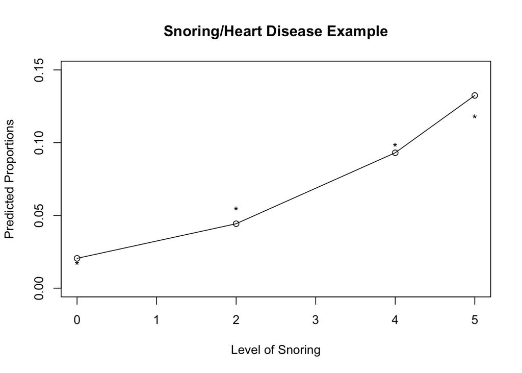

```r
plot(snore$snore,snore.sample.props,xlab="Level of Snoring",ylab ="Predicted Proportions",main="Snoring/Heart Disease Example",ylim=c(0,.15), pch="*")
lines(snore$snore,fitted(snore.glm_logit),type="o")
```

- want a smoother fit? use ‘predict.glm’

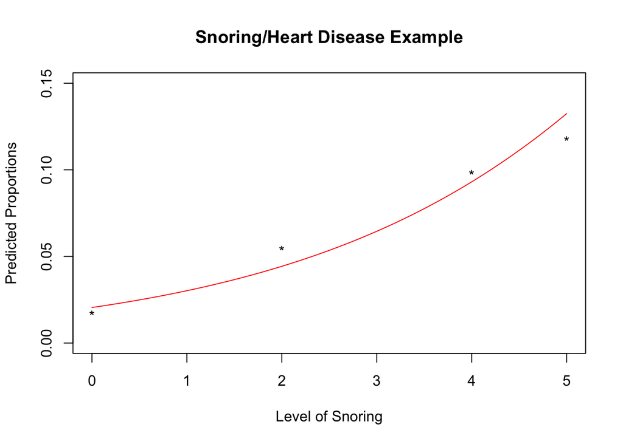

```r
plot(snore$snore,snore.sample.props,xlab="Level of Snoring",ylab ="Predicted Proportions",main="Snoring/Heart Disease Example",ylim=c(0,.15), pch="*")
snore.predict_logit = predict.glm(snore.glm_logit,type="response",newdata=data.frame(snore=seq(0,5,.1)))
lines(seq(0,5,.1),snore.predict_logit,col="red")
```

- want the linear responses at the 4 levels of snoring

```r
predict.glm(snore.glm_logit,type="link")
```

```
##         1         2         3         4
## -3.866248 -3.071575 -2.276902 -1.879565
```

- This time, we fit a probit model to the data

$$\pi(x) = \Phi(\alpha + \beta x)$$

$$\Phi^{-1}[\pi(x)] = \alpha + \beta x$$

where $\Phi$ is the cdf of standard normal distribution.

```r
snore.glm_probit = glm(cbind(yes,no) ~ snore,data=snore,family=binomial(link = "probit"))
summary(snore.glm_probit)
```

```
##
## Call:
## glm(formula = cbind(yes, no) ~ snore, family = binomial(link = "probit"),
##     data = snore)
##
## Deviance Residuals:
##       1        2        3        4
## -0.6188   1.0388   0.1684  -0.6175
##
## Coefficients:
##             Estimate Std. Error z value Pr(>|z|)
## (Intercept) -2.06055    0.07017 -29.367  < 2e-16 ***
## snore        0.18777    0.02348   7.997 1.28e-15 ***
## ---
## Signif. codes:  0 '***' 0.001 '**' 0.01 '*' 0.05 '.' 0.1 ' ' 1
##
## (Dispersion parameter for binomial family taken to be 1)
##
##     Null deviance: 65.9045  on 3  degrees of freedom
## Residual deviance:  1.8716  on 2  degrees of freedom
## AIC: 26.124
##
## Number of Fisher Scoring iterations: 4
```

- get the coefficients

```r
coef(snore.glm_probit)
```

```
## (Intercept)       snore
##  -2.0605516   0.1877705
```

- Get the predict proportions, rounded to 3 digits

```r
round(fitted(snore.glm_probit),3)
```

```
##     1     2     3     4
## 0.020 0.046 0.095 0.131
```

```r
snore$logit_fitted<-round(fitted(snore.glm_logit),3)
snore$probit_fitted<-round(fitted(snore.glm_probit),3)
snore
```

```
##   snore yes   no sample_prop logit_fitted probit_fitted
## 1     0  24 1355       0.017        0.021         0.020
## 2     2  35  603       0.055        0.044         0.046
## 3     4  21  192       0.099        0.093         0.095
## 4     5  30  224       0.118        0.132         0.131
```

- add the fitted proportions to the plot

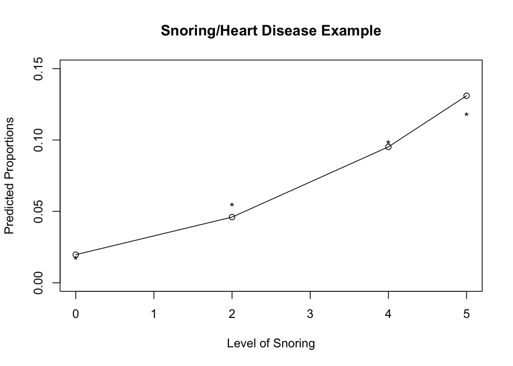

```r
plot(snore$snore,snore.sample.props,xlab="Level of Snoring",ylab ="Predicted Proportions",main="Snoring/Heart Disease Example",ylim=c(0,.15), pch="*")
lines(snore$snore,fitted(snore.glm_probit),type="o")
```

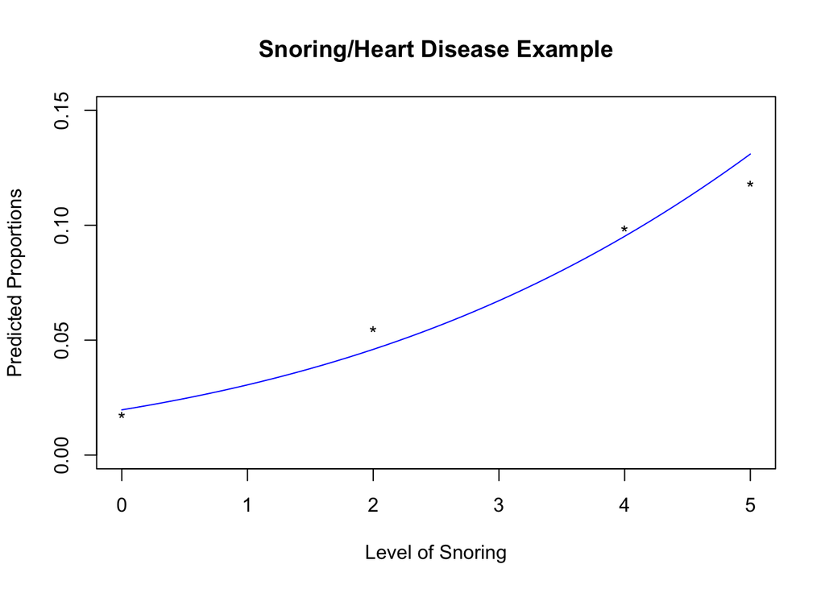

```r
plot(snore$snore,snore.sample.props,xlab="Level of Snoring",ylab ="Predicted Proportions",main="Snoring/Heart Disease Example",ylim=c(0,.15), pch="*")
snore.predict_probit = predict.glm(snore.glm_probit,type="response",newdata=data.frame(snore=seq(0,5,.1)))
lines(seq(0,5,.1), snore.predict_probit,col="blue")
```

- Logistic vs. Probit

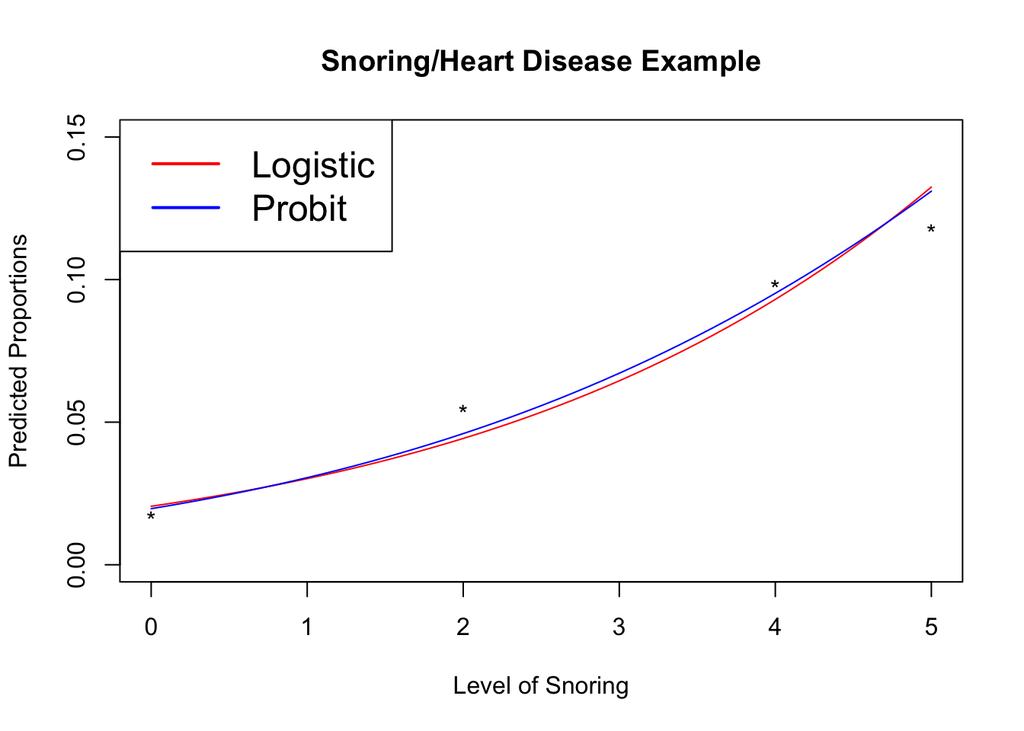

```r
plot(snore$snore,snore.sample.props,xlab="Level of Snoring",ylab ="Predicted Proportions",main="Snoring/Heart Disease Example",ylim=c(0,.15), pch="*")

lines(seq(0,5,.1), snore.predict_logit,col="red")
lines(seq(0,5,.1), snore.predict_probit,col="blue")
legend("topleft" ,c("Logistic","Probit"),
       lwd=c(2,2),
       col=c("red","blue"),cex=1.5)
```

## 5. Inference for GLM: Deviance and Goodness of Fit

For logistic glm, we assume that
$$\log \left( \frac{\pi(x)}{1-\pi(x)} \right) = \alpha + \beta x$$
$\Rightarrow$ we use 2 parameters.

- Saturated model
  - Model with a perfect fit $\hat{\mu}_i = y_i$, $i=1, \ldots, n$
  - Model with a maximum number of parameters
  - Used as a criterion to be compared to several other models
  - Contains more parameters than the our assumed model
- LS : The maximum log likelihood value of the saturated model. Denote: $\ell (y;y)$
- LM : The maximum log likelihood value of the assumed model. Denote: $\ell(\hat{\mu} ;y)$

$$\mbox{LS} ≥ \mbox{LM}$$

- Deviance : goodness-of-fit statistic for a statistical model.
  $$\mbox{Deviance}=D(y,\hat{\mu} ):=−2(\mbox{LM}−\mbox{LS})=2\log\frac{\ell (y;y)}{\ell(\hat{\mu};y)}$$
  That is, LRT for comparing a saturated model $S$ and fitted model $\hat{\mu}$
  $\Rightarrow$ It follws approximately $\chi_{df}^2$ distribution, where $df$=difference number of the parameters (# of parameters in $S$ - # of parameters in $\hat{\mu}$).
- Statistic has high value, $p$ has low value implies assumed model do not fit well.

```r
snore.glm_logit
```

```
##
## Call:  glm(formula = cbind(yes, no) ~ snore, family = binomial(link = "logit"),
##     data = snore)
##
## Coefficients:
## (Intercept)        snore
##     -3.8662       0.3973
##
## Degrees of Freedom: 3 Total (i.e. Null);  2 Residual
## Null Deviance:       65.9
## Residual Deviance: 2.809     AIC: 27.06
```

- Null Deviance means deviance difference between Saturated model and simple model( do not care of snoring effect)

```r
Dev_logit<-snore.glm_logit$deviance
Dev_logit
```

```
## [1] 2.808912
```

```r
1-pchisq(Dev_logit,2)
```

```
## [1] 0.2455006
```

p>>0.05 means logistic model fits well.

- want deviance residuals from the logit model?
  - Deviance residual
    $$r_{D_i}=\mbox{sign}(y_i-\hat{\mu}_i)\sqrt{D(y_i;\hat{\mu}_i)a(\phi)}$$
  - Perason residual
    $$r_{P_i} = \frac{y_i-\hat{\mu}_i}{sd(\hat{\mu}_i)}$$
  - When the model holds, Pearson and deviance residuals are less variable than standard normal

```r
residuals.glm(snore.glm_logit,type="deviance")
```

```
##          1          2          3          4
## -0.8346344  1.2520731  0.2757747 -0.6845134
```

- summary also has an attribute named deviance.resid

```r
summary(snore.glm_logit)$deviance.resid
```

```
##          1          2          3          4
## -0.8346344  1.2520731  0.2757747 -0.6845134
```

- how about Pearson residuals?

```r
snore.pres = residuals.glm(snore.glm_logit,type="pearson")
snore.pres
```

```
##          1          2          3          4
## -0.8131634  1.2968557  0.2781891 -0.6736948
```

- what of standardized residuals? —Just a little more work

```r
snore.pres/sqrt(1-influence(snore.glm_logit)$hat)
```

```
##          1          2          3          4
## -1.6783847  1.5448873  0.3225535 -1.1970179
```

- influence is a function that provides basic quantities used in diagnostics for regression models

```r
influence(snore.glm_logit)
```

```
## $hat
##         1         2         3         4
## 0.7652678 0.2953236 0.2561647 0.6832438
##
## $coefficients
##    (Intercept)        snore
## 1 -0.517010000  0.124900565
## 2  0.131849691 -0.015440357
## 3  0.001462199  0.005234459
## 4  0.067057767 -0.068073860
##
## $sigma
##         1         2         3         4
##       NaN 0.7643436 1.6451958 1.1531137
##
## $dev.res
##          1          2          3          4
## -0.8346344  1.2520731  0.2757747 -0.6845134
##
## $pear.res
##          1          2          3          4
## -0.8131634  1.2968557  0.2781891 -0.6736948
```

- also check out ‘influence.measures’ which gives regression deletion diagnostics

```r
influence.measures(snore.glm_logit)
```

```
## Influence measures of
##   glm(formula = cbind(yes, no) ~ snore, family = binomial(link = "logit"),      data = snore) :
##
##    dfb.1_ dfb.snor  dffit cov.r cook.d   hat inf
## 1     NaN      NaN    NaN   NaN 4.5919 0.765   *
## 2 1.03782  -0.4039  1.263 0.246 0.5001 0.295   *
## 3 0.00535   0.0636  0.114 4.993 0.0179 0.256   *
## 4 0.34987  -1.1804 -1.549 2.830 1.5453 0.683   *
```

- Diagnostic plots

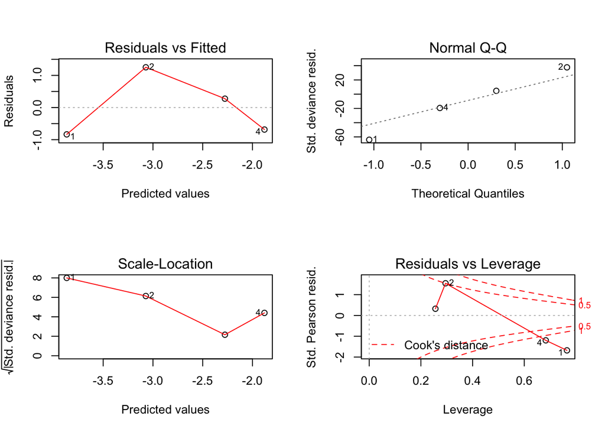

```r
par(mfrow=c(2,2))
plot(snore.glm_logit)
```

## 6. Introduction to Deep Learning (Using Keras)

### cf. Neural Networks

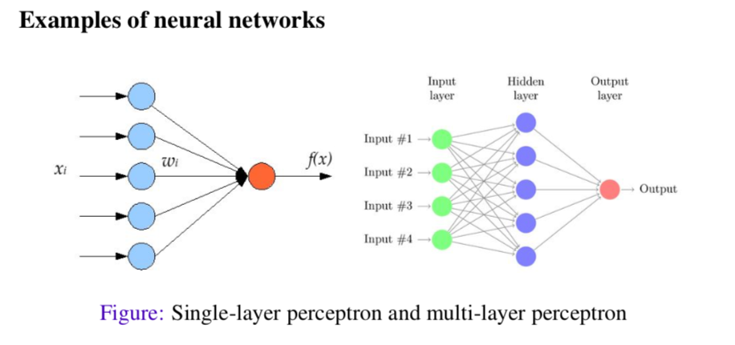

- Consider the neural network $K$-class classification model that has one hidden layer:

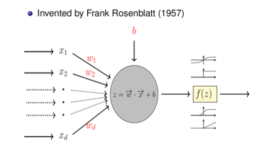

$$\begin{eqnarray*}
z_m^{(0)} &=& b_m^{(0)} + \mathrm{w}_m^{(0)T} \mathrm{x}, &~ m=1, \ldots, M\\
h_m &=& \sigma(z_m^{(0)}), &~ m=1, \ldots, M\\
z_k^{(1)} &=& b_k^{(1)}+\mathrm{w}_k^{(1)T}\mathrm{h}, &~ k=1, \ldots, K\\
f_k(\mathrm{x}) &=& g_k(\mathrm{z}), &~ k=1, \ldots, K
\end{eqnarray*}$$
where $\mathrm{x}=(x_1, \ldots, x_p)$, $\mathrm{h}=(h_1, \ldots, h_M)$ and $M$ is the number of class of hidden layer.

- Notations
  - $x_p$, $i=1, \ldots, p$ : input node
  - $h_m$, $m=1,\ldots, M$ : hidden node
  - $y_k$, $k=1, \ldots, K$ : ouput (response) node
  - $\mathrm{w}_m^{(0)}, \mathrm{w}_m^{(1)}$ : weight vector
  - $b_m^{(0)}, b_m^{(1)}$ : bias
  - $g_k$ : output function
- $\sigma(\cdot)$ is a nonlinear transformation which is the activation function.
  - Sigmoid function :
    $$sigmoid(x) = \frac{\exp(x)}{1+\exp(x)}$$
  - tanh function :
    $$tanh(x) = \frac{\exp(x) - \exp(-x)}{\exp(x) + \exp(-x)}$$
  - softmax function (classification case) :
    $$g_k(\mathrm{z}) = \frac{\exp(z_k)}{\sum_{l=1}^{K}\exp(z_l)}, ~~ k=1,\ldots, K$$
  - Identity function (Regression case) :
    $$g_k(\mathrm{z})=\mathrm{z}, ~~ k=1, \ldots, K$$

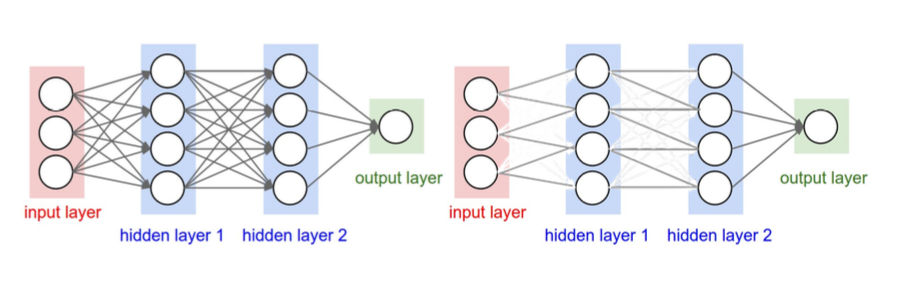

#### 0. Install

- With Python
  1. Install Python 3.5: https://www.python.org/downloads/release/python-353/
  2. Install Anaconda: https://www.anaconda.com/download/
  3. Install TensorFlow
- With R
  1. Install Python 3.5: https://www.python.org/downloads/release/python-353/
  2. Install Anaconda: https://www.anaconda.com/download/
  3. Install TensorFlow
  4. install.packages(“keras”)
- With colab: https://colab.research.google.com/

#### 1. Deep Neural Network Architecture

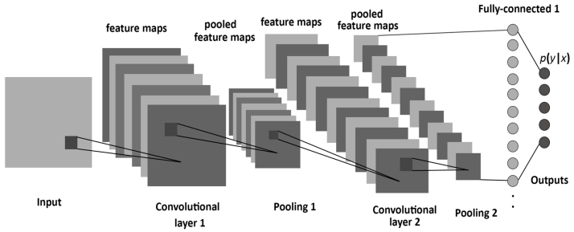

#### 2. Data Augmentation

In Keras, We have a ImageDataGenerator class that is used to generate batches of tensor image data with real-time data augmentation. The data will be looped over (in batches) indefinitely. The image data is generated by transforming the actual training images by rotation, crop, shifts, shear, zoom, flip, reflection, normalization etc.

#### 3. Regularization

Deep neural nets with a large number of parameters are very powerful machine learning systems. However, overfitting is a serious problem in such networks. Given below are few techniques which were proposed recently and has become a general norm these days in convolutional neural networks.

- **Dropout** The key idea is to randomly drop units (along with their connections) from the neural network during training. The reduction in number of parameters in each step of training has effect of regularization.
- **Kernel_regularizer** allows to apply penalties on layer parameters during optimization. These penalties are incorporated in the loss function that the network optimizes.
- **BatchNormalization** normalizes the activation of the previous layer at each batch, i.e. applies a transformation that maintains the mean activation close to 0 and the activation standard deviation close to 1. It addresses the problem of internal covariate shift.
- **Polling**

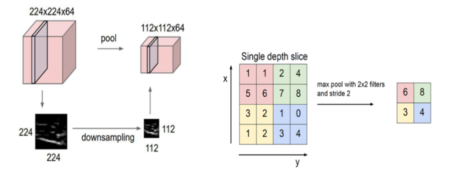

#### 4. Notations

- Epoch: One Epoch is when an ENTIRE dataset is passed forward and backward through the neural network only ONCE
- Batch size: Total number of training examples present in a single batch.
- Iteration: The number of passes to complete one epoch.

Hence, 1 epoch = (# of data/batch size) iterations.

#### 5. Alexnet

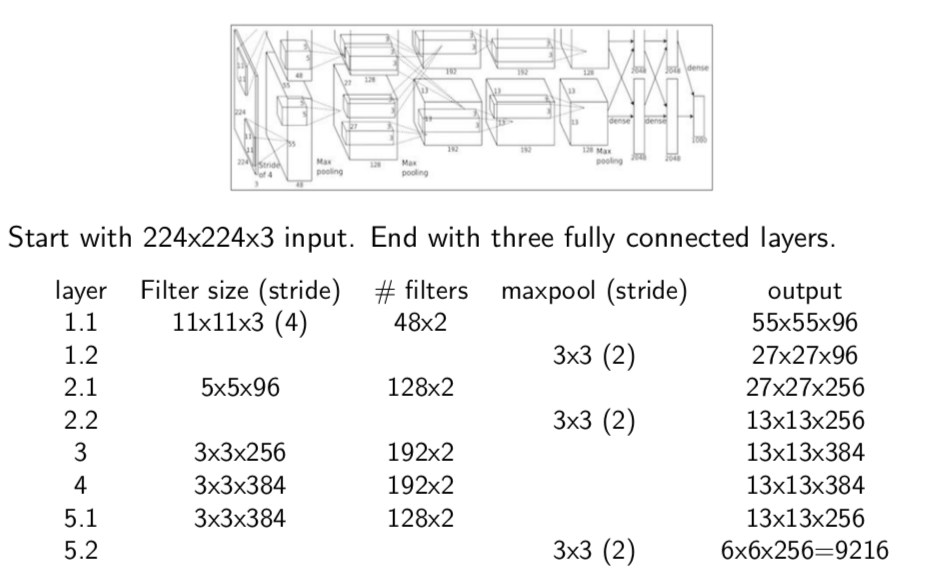